# Data Reporting Class Story Pitch

Jessica Baugh

2025-10-16

# **Hundreds of unaccompanied migrant children go to a rural Washington County, and its classrooms.**

Mason County received 412 unaccompanied children from January 2015 through May 2023, according to data from the U.S. Department of Health and Human Services. This is more than triple the county average in Washington state. Of these children, 60% were placed with non-parent sponsors.

Since 2015, there has been a similar number of migrant children arriving. As they arrive and adapt to living in Mason County, school can be a place of support and structure. Do the local schools in Mason County have programs to help this population of students settle?

This reporting will build on The New York Times’ investigation “Where Migrant Children Are Living, and Often Working, in the U.S.,” which marked Mason County as the hotspot of Washington for non-parent sponsor placements. Exploring how or if school districts address this population of children can show how local policies and organizations have adapted to account for the number of migrant children coming to Mason County.

# Setup

```r
# Loading necessary packages
pacman::p_load(tidyverse, lubridate, janitor, tidycensus, zipcodeR, stringr)

# Loading in the NYTimes dataset from GitHub
nyt_mc <- read_csv("data.csv", col_types = cols(ID = col_character(),
    `Child's Date of Entry` = col_date(format = "%m/%d/%y"),
    `Child's Date of Release` = col_date(format = "%m/%d/%y"),
    `Sponsor Category` = col_character()))
nyt_mc <- clean_names(nyt_mc)

# Selecting the Mason County zipcodes
mason_zips <- c("98524","98528","98546","98548","98555","98560","98584","98588","98592")

mason_mc <- nyt_mc %>%
  mutate(
    sponsor_zip_5 = str_extract(as.character(sponsor_zipcode), "^\\d{5}")
  ) %>%
  filter(sponsor_zip_5 %in% mason_zips)
```

## When migrant children come to Mason County, 60% of them do not go to parent sponsors. Most go to immediate relatives, such as a sibling, aunt, uncle or cousin.

### Visualization 1

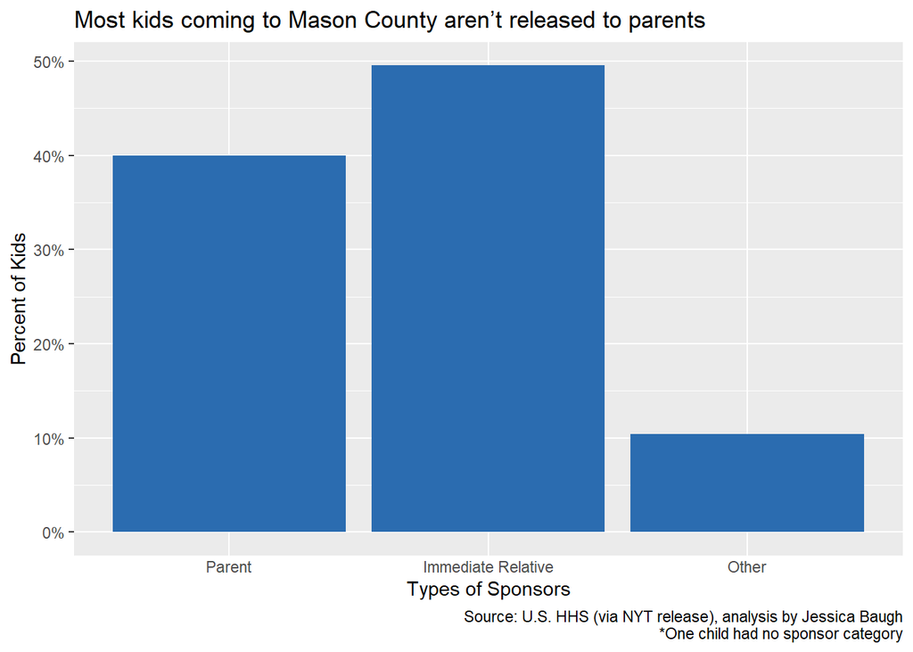

```r
# summarize and calculate percentage
top_sponsors_summary <- mason_mc %>%
  filter(!is.na(sponsor_category)) %>%
  group_by(sponsor_category) %>%
  summarize(kids = n()) %>%
  mutate(percent = kids / sum(kids))

# ploting and creating the visual in ggplot
pA <- top_sponsors_summary %>%
  ggplot(aes(x = sponsor_category, y = percent)) +
  geom_col(fill = "#2b6cb0") +
  scale_y_continuous(labels = scales::percent_format()) +
  scale_x_discrete(
    labels = c(
      "Parent",
      "Immediate Relative",
      "Other"
    )
  ) +
  labs(
    title = "Most kids coming to Mason County aren’t released to parents",
    caption = "Source: U.S. HHS (via NYT release), analysis by Jessica Baugh
       *One child had no sponsor category",
    x = "Types of Sponsors",
    y = "Percent of Kids"
  ) +
  theme(axis.ticks.x = element_blank())

pA
```

## Since 2015, the number of children going to non-parents generally rises and falls along with the overall number of children entering the county. However, in some quarters, all of the children go to non-parent sponsors, including most recently in 2022.

### **Visualization 2**

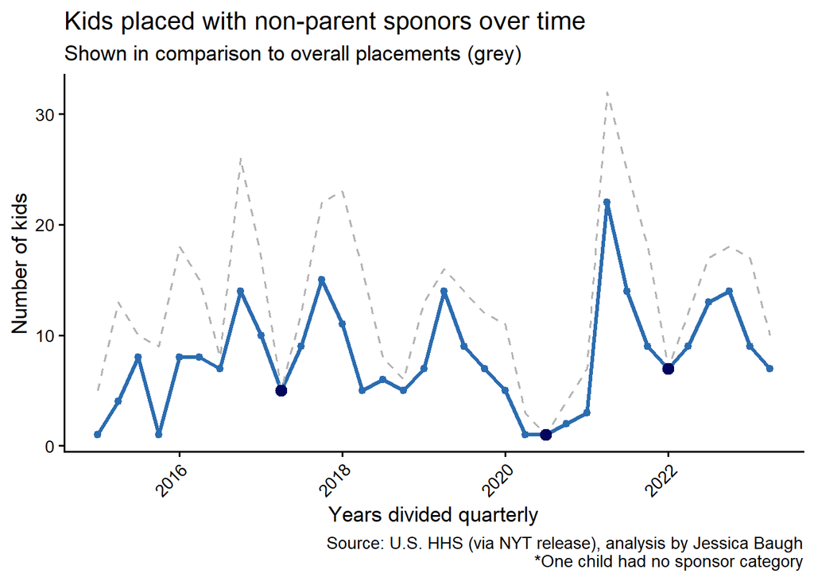

```r
# organizing the data to create the line chart
nonparent_q <- mason_mc %>%
  filter(!is.na(childs_date_of_release), sponsor_category %in% 1:3) %>%
  mutate(qtr = floor_date(as.Date(childs_date_of_release), "quarter"),
         is_non_parent = sponsor_category != 1) %>%
  group_by(qtr) %>%
  summarise(non_parent_count = sum(is_non_parent), total = n(), .groups = "drop")

# plotting and creating the visual in ggplot
pB <- ggplot(nonparent_q, aes(qtr, non_parent_count)) +
  geom_line(linewidth = 1.2, color = "#2b6cb0") +
  geom_point(size = 1.8, color = "#2b6cb0") +
  geom_line(aes(y = total), color = "grey70", linetype = "dashed") +
  geom_point(
    data = subset(nonparent_q, non_parent_count == total),
    aes(y = non_parent_count),
    color = "#02075d",
    size = 3
  ) +
  labs(
    title = "Kids placed with non-parent sponors over time",
        subtitle= "Shown in comparison to overall placements (grey)",
    x = "Years divided quarterly",
    y = "Number of kids",
    caption = "Source: U.S. HHS (via NYT release), analysis by Jessica Baugh
    *One child had no sponsor category"
  ) +
  theme_classic(base_size = 13) +
  theme(axis.text.x = element_text(angle = 45, hjust = 1))

pB
```

## Mason County has the highest share of kids going to non-parent sponsors in Washington. Adams County is second, and all other counties have much lower rates.

### Visualization 3

### Load WA population data

```r
# using census data to get county population data
wa_county_map <- get_acs(
  geography = "county",
  state = "wa",
  variables = "B01003_001",
  geometry = T
)
```

[output not shown]

### Getting + joining zipcode data

```r
# Getting zipcode data for WA
zip_to_county_WA <- zipcodeR::zip_code_db %>%
  filter(state == "WA") %>%
  transmute(
    sponsor_zipcode = zipcode,
    county   = county,
  )

# Joining data and narrowing it down
wa_nonparent <- nyt_mc %>%
  left_join(zip_to_county_WA, by = "sponsor_zipcode") %>%
  filter(
    !is.na(county),
    sponsor_category %in% c("2","3")
  )
```

### Assigning zipcodes to counties

```r
# Build WA county FIPS from names
norm_county <- function(x) {
  x |>
    stringr::str_to_lower() |>
    stringr::str_replace_all("\\bcounty\\b", "") |>
    stringr::str_replace_all("[^a-z ]", " ") |>
    stringr::str_squish()
}

wa_fips <- tidycensus::fips_codes %>%
  filter(state == "WA") %>%
  transmute(
    county_name_clean = norm_county(county),               # "mason"
    county_fips       = paste0(state_code, county_code)    # e.g., "53045"
  ) %>%
  distinct()

wa_counts <- wa_nonparent %>%
  mutate(county_name_clean = norm_county(county)) %>%
  inner_join(wa_fips, by = "county_name_clean") %>%
  count(county_fips, name = "children_nonparent")
```

### Joining counts with shapes/population + finding rate

```r
wa_rates <- wa_county_map %>%
  mutate(GEOID = as.character(GEOID)) %>%
  transmute(
    county_fips = stringr::str_pad(GEOID, width = 5, pad = "0"),
    county_name = NAME,
    population  = estimate,
    geometry
  ) %>%
  left_join(wa_counts, by = "county_fips") %>%
  mutate(
    children_nonparent = tidyr::replace_na(children_nonparent, 0L),
    rate_per_100k      = 100000 * children_nonparent / population
  )
```

### Creating visualization

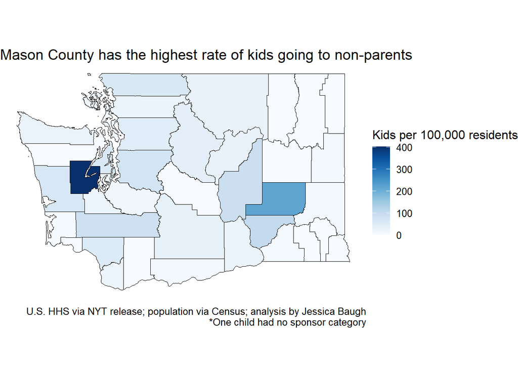

```r
brks <- round(pretty(range(wa_rates$rate_per_100k, na.rm = TRUE), n = 5))

p_rate <- ggplot(wa_rates, aes(fill = rate_per_100k)) +
  geom_sf(color = "black", linewidth = 0.25) +
 scale_fill_gradientn(
  colors = RColorBrewer::brewer.pal(9, "Blues"),
  breaks = brks,  # ← integer ticks
  labels = function(x) formatC(x, format = "f", digits = 0, big.mark = ","),  # ← no decimals
  na.value = "grey90",
  name = "Kids per 100,000 residents"
) +
  labs(
    title    = "Mason County has the highest rate of kids going to non-parents",
    caption  = "U.S. HHS via NYT release; population via Census; analysis by Jessica Baugh
    *One child had no sponsor category",
    x = NULL, y = NULL
  ) +
  theme_void(base_size = 12) +
  theme(legend.position = "right")

p_rate
```